# R Notebook

## Description

This notebook looks at how the number of correctly predicted drugs varies with K. In this case, we don’t consider just the top 5 targets predicted for a given drug. We instead look at all the targets voted on by the K neighbours.

```r
knitr::opts_knit$set(root.dir=normalizePath("../../"))
```

```r
rm(list=ls())
set.seed(9833)
library(plotly)
library(ggplot2)
library(ROCR)
library(reshape2)
library(caret)
library(SNFtool)
library(org.Hs.eg.db)
library(doParallel)
library(foreach)
library(missForest)
source("RCode/flexible_layers/sensitivityDataFlexible.R")
source("RCode/flexible_layers/perturbationDataFlexible.R")
source("RCode/flexible_layers/perturbationDataFlexibleCustomSig.R")
source("RCode/flexible_layers/structureDataFlexible.R")
source("RCode/flexible_layers/imagingDataFlexible.R")
source("RCode/flexible_layers/constImagingLayerFlexible.R")
source("RCode/flexible_layers/constSensitivityLayerFlexible.R")
source("RCode/flexible_layers/constPerturbationLayerFlexible.R")
source("RCode/flexible_layers/constStructureLayerFlexible.R")
source("RCode/flexible_layers/drugTargetBenchFlexible.R")
source("RCode/value_inference_models/modifying_snf/snfModifiedHelpers.R")
source("RCode/knn/knnHelpers.R")
source("RCode/knn/drugTargetsKNN.R")
source("RCode/goldenberg_imputation/medianSimilarity.R")
source("notebooks/investigating_difficult_drugs/badPerformerHelpers.R")
badchars <- "[\xb5]|[\n]|[,]|[;]|[:]|[-]|[+]|[*]|[%]|[$]|[#]|[{]|[}]|[[]|[]]|[|]|[\\^]|[/]|[\\]|[.]|[_]|[ ]"
```

## Experiments on CTRPv2 Drug Target Data

### Load Data For Layers

We start by loading in the lincs metadata file which is used to match senstivity drug names to the l1000 signatures since are indexed according to pert_id instead of pert_iname. It also contains the smiles strings for all the compounds in L1000, and these are used to create the structure layer.

```r
lincs.meta <- read.csv("Data/LINCS.csv", stringsAsFactors = FALSE)
lincs.meta$pert_iname <- toupper(lincs.meta$pert_iname)
lincs.meta$pert_iname <- gsub(badchars, "", lincs.meta$pert_iname)
```

Now to load in the sensitivity correlations and the pert signatures

```r
sensitivity.file.name <- "Data/combined_sensitivity//combined_sens_iname_replaced.RData"
sens.data <- SensitivityDataFlexible(sensitivity.file.name)  ## 645 X 239
pert.data.new <- PerturbationDataFlexibleCustomSig("Data/pert_sigs_6_hour/pert_features_full.RData")
```

Keep in mind that the new signatures are missing 8 drugs since they were computed on only 9 cell lines. Thus, when we compute the common drugs later, they should be based on the intersection between sens and the new pert signatures.

Subset the lincs metadata file to only the drugs appearing in the sensitivity layer

```r
sens.names <- rownames(sens.data)
lincs.meta.subset <- lincs.meta[match(sens.names, lincs.meta$pert_iname),]
lincs.meta.subset <- lincs.meta.subset[!is.na(lincs.meta.subset$X),]
```

Now we create the structure fingerprints based on the subsetted lincs metadata

```r
strc.data <- StructureDataFlexible(lincs.meta.subset)  ## a vector  --> 239 elemnts
```

### Find Common Drugs

Notice how we aren’t including the pert layer when determining the common drugs. We already know that it is missing 8 drugs, so those drugs will just be imputed later on.

```r
layers <- list(sens.names = sort(colnames(sens.data)),
               strc.names = names(strc.data))
common.drugs <- Reduce(intersect, Filter(Negate(is.null),layers))
print(length(common.drugs))
```

[output not shown]

### Create Similarity Matrices

```r
data.bench <- DrugTargetsKNN(common.drugs, gmt_file_name="temp", use.ctrpv2=TRUE,
                        use.clue=FALSE, use.chembl=FALSE, use.dbank=FALSE, use.dtc=FALSE)
data.bench[] <- lapply(data.bench, as.character)
benchmark.drugs <- unique(data.bench$MOLECULE_NAME)
```

```r
sens.cor <- sens.data[common.drugs, common.drugs]
pert.cor.new <- cor(pert.data.new[, intersect(common.drugs, colnames(pert.data.new))], method="pearson", use="pairwise.complete.obs")
registerDoParallel(4)
# Impute missing data
pert.cor.new <- missForest(pert.cor.new, maxiter=10, parallelize = "variables")$ximp
```

```
  missForest iteration 1 in progress...done!
  missForest iteration 2 in progress...done!
  missForest iteration 3 in progress...done!
  missForest iteration 4 in progress...done!
```

```r
strc.cor <- fingerprint::fp.sim.matrix(strc.data[common.drugs], method = "tanimoto")
rownames(strc.cor) <- names(strc.data[common.drugs])
colnames(strc.cor) <- names(strc.data[common.drugs])
```

### Integrate Layers

```r
all.drugs <- common.drugs
correlation.matrices <- list(sens=sens.cor, pert=pert.cor.new, strc=strc.cor)
integrated <- IntegrateCorrelationMatrices(correlation.matrices, all.drugs)
```

### Determine Sensitivity For Each Value of K

```r
num.neighbours <- 1:50
accuracies <- list()
top = 1000

for (k in num.neighbours) {
    acc <- GetKNNAccuracy(k, integrated, data.bench, top=top)

    if (k == 1) {
        prediction.status <- acc
    } else {
        prediction.status[(prediction.status == 0 & acc == 1)] <- k
    }

    acc <- sum(acc) / length(acc)

    accuracies[[k]] <- acc
}
```

### Visualize How Sensitivity Increases

```r
df.data <- unlist(accuracies)
df.data <- cbind(as.character(num.neighbours), df.data)
df.data <- as.data.frame(df.data, stringsAsFactors=F)
colnames(df.data) <- c("k", "acc")
df.data$acc <- as.numeric(df.data$acc)
df.data <- df.data[1:20, ]

p <- ggplot(data=df.data, aes(x=factor(k, levels=k), y=acc, group=1))
p <- p + geom_line(stat="identity")
p <- p + xlab("K")
p <- p + ylab("Accuracy")
p <- p + ggtitle("Accuracy vs. K on CTRPv2")
p
```

[output not shown]

### Visualize Accuracy Per Drug Class

Let’s load in the file provided by Wail to map the drugs to classes

```r
mapping.table <- read.delim("Data/drug_class_mapping/CTRPv2Drugs_BasedOnGDSC1000_Nehme.csv",
                           sep="\t", stringsAsFactors = F)
mapping.table$Drugs <- toupper(mapping.table$Drugs)
mapping.table$Drugs <- gsub(badchars, "", mapping.table$Drugs)
pred.status.mapped <- prediction.status
names(pred.status.mapped) <- mapping.table$PossibleGDSC1000Class[match(names(pred.status.mapped), mapping.table$Drugs)]
```

Now we can create the dataframe to be used by ggplot

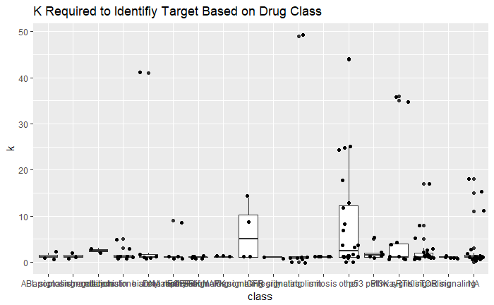

```r
df.data <- cbind(names(pred.status.mapped), pred.status.mapped)
df.data <- as.data.frame(df.data, stringsAsFactors=F)
colnames(df.data) <- c("class", "k")
df.data$k <- as.numeric(df.data$k)
p <- ggplot(data=df.data, aes(x=class, y=k))
p <- p + geom_boxplot()
p <- p + geom_jitter()
p <- p + ggtitle("K Required to Identifiy Target Based on Drug Class")
p
```

## Experiments On Combined Drug Target Benchmark

```r
data.bench <- DrugTargetsKNN(common.drugs, gmt_file_name="temp", use.ctrpv2=TRUE,
                        use.clue=TRUE, use.chembl=TRUE, use.dbank=TRUE, use.dtc=FALSE)
data.bench[] <- lapply(data.bench, as.character)
benchmark.drugs <- unique(data.bench$MOLECULE_NAME)
```

### Determine Sensitivity For Each Value of K

```r
num.neighbours <- 1:50
accuracies <- list()
top = 1000
for (k in num.neighbours) {
    acc <- GetKNNAccuracy(k, integrated, data.bench, top=top)

    if (k == 1) {
        prediction.status <- acc
    } else {
        prediction.status[(prediction.status == 0 & acc == 1)] <- k
    }

    acc <- sum(acc) / length(acc)

    accuracies[[k]] <- acc
}
```

### Visualize How Sensitivity Increases

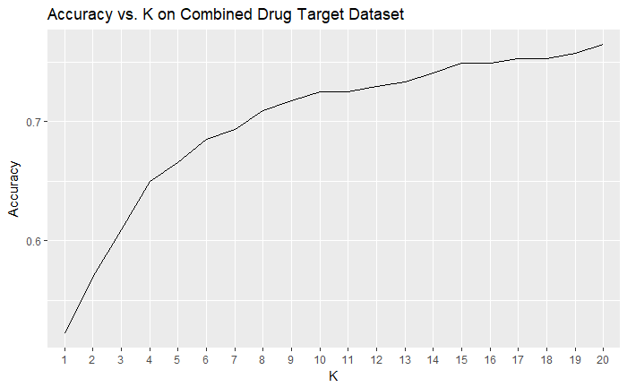

```r
df.data <- unlist(accuracies)
df.data <- cbind(as.character(num.neighbours), df.data)
df.data <- as.data.frame(df.data, stringsAsFactors=F)
colnames(df.data) <- c("k", "acc")
df.data$acc <- as.numeric(df.data$acc)
df.data <- df.data[1:20, ]
p <- ggplot(data=df.data, aes(x=factor(k, levels=k), y=acc, group=1))
p <- p + geom_line(stat="identity")
p <- p + xlab("K")
p <- p + ylab("Accuracy")
p <- p + ggtitle("Accuracy vs. K on Combined Drug Target Dataset")
p
```

### Visualize Accuracy Per Drug Class

```r
names(pred.status.mapped)[!(names(pred.status.mapped %in% union(mapping.table.ctrpv2$PossibleGDSC1000Class, mapping.table.gdsc1000$TARGET.PATHWAY))] <- "other"
```

[output not shown]

Now we can create the dataframe to be used by ggplot

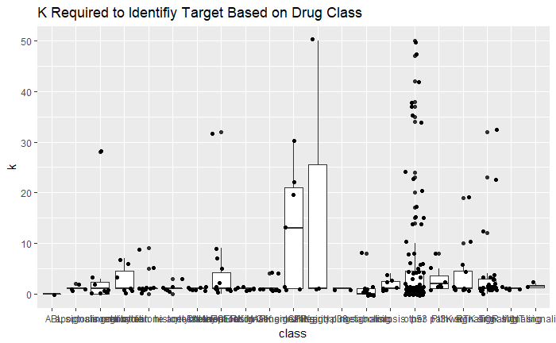

```r
df.data <- cbind(names(pred.status.mapped), pred.status.mapped)
df.data <- as.data.frame(df.data, stringsAsFactors=F)
colnames(df.data) <- c("class", "k")
df.data$k <- as.numeric(df.data$k)
p <- ggplot(data=df.data, aes(x=class, y=k))
p <- p + geom_boxplot()
p <- p + geom_jitter()
p <- p + ggtitle("K Required to Identifiy Target Based on Drug Class")
p
```